# Computer Practical 5: Data analysis and manipulation in R

## Summarise by group with the earthworm dataset

Lets practice summarising per group using the earthworm dataset you analysed in Prac 4.

The dataset consists of data from 92 x 1m squared plots across different habitat types. At each of these 92 plots, the researchers collected data how how many species of earthworms they found, as well as the total abundance.

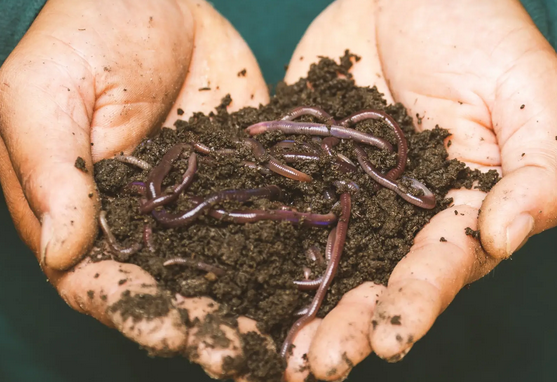

If worm_data is not already in your working environment, upload it again.

Lets summarise the mean earthworm abundance per habitat type. To do this, we use the coding structure:

**data %>%** # take your dataset

**group_by(X) %>%** # then group by categorical variable X

**summarise(mean_y = mean(Y))** # then calculate the mean of Y by X

```r
worm_data %>%                                        # take worm_data
  group_by(habitat_type) %>%                         # group by habitat type
  summarise(max_abundance = max(worm_abundance))     # return the max of worm_abundance (per habitat type) and call new column 'max_abundance'
```

| habitat_type | max_abundance |
| --- | --- |
| Farmland | 130 |
| Forest | 149 |
| Garden | 150 |
| Unknown | 115 |

```r
# max number of worms found in farmland = 130, forest = 149, and garden = 150
```

In the example above, I have used the max() function to calculate the maximum for each category of habitat_type. However, you can change this to any function you like.

**You will need to refer to this table for the following exercises:**

| Summary statistic | Function |
| --- | --- |
| Maximum | max() |
| Minimim | min() |
| Mean | mean() |
| Median | median() |
| Standard deviation | sd() |
| Sum | sum() |
| Number of observations | n() |
| Number of unique observations | n_distinct() |
| Keep only unique observations | unique() |

You should note that ‘**max_abundance**’ used in the example above is **just a name I chose for the new column that contains the summary data** - in this case the maximum values per habitat type. You can change this to anything you like, for example:

```r
worm_data %>%
  group_by(habitat_type) %>%
  summarise(MAXIMUM_WORMS = max(worm_abundance)) #<-- note change here
```

| habitat_type | MAXIMUM_WORMS |
| --- | --- |
| Farmland | 130 |
| Forest | 149 |
| Garden | 150 |
| Unknown | 115 |

Notice how the new column in the output now says MAXIMUM_WORMS.

#### Exercise 1

Edit the code above to calculate the **minimum** worm abundance per habitat type.

```r
worm_data %>%
  group_by(habitat_type) %>%
  summarise(min_abundance = min(worm_abundance))
```

| habitat_type | min_abundance |
| --- | --- |
| Farmland | 14 |
| Forest | 44 |
| Garden | 40 |
| Unknown | 36 |

#### Exercise 2

Calculate the mean **worm diversity** per habitat type.

```r
worm_data %>%
  group_by(habitat_type) %>%
  summarise(mean_diversity = mean(worm_abundance))
```

[output not shown]

You can calculate summaries for more than one variable by adding multiple variables to the group_by() function.

For example, lets calculate the total sum of rainfall per habitat type AND month:

```r
worm_data %>%
  group_by(habitat_type, month) %>%
  summarise(total_rainfall = sum(rainfall_mm))
```

| habitat_type | month | total_rainfall |
| --- | --- | --- |
| Farmland | 5 | 731.4 |
| Farmland | 6 | 324.9 |
| Farmland | 7 | 496.0 |
| Forest | 5 | 459.9 |
| Forest | 6 | 409.2 |
| Forest | 7 | 583.7 |
| Garden | 5 | 363.1 |
| Garden | 6 | 336.7 |
| Garden | 7 | 923.7 |
| Unknown | 5 | 64.4 |

[output cut: 1 more lines]